# RNA-seq数据基因调控网络分析

分子细胞科学卓越创新中心生物信息平台

18 June 2020

#### Abstract

本文描述了bulk RNA-seq分析流程中基因调控网络子模块，该模块可以得到转录因子与靶基因之间的调控网络关系。该模块用R语言编写。

# 1 分析流程示意图

该模块需要输入两方面的信息，利用基因表达量和转录因子列表来完成调控网络分析，表达量可用来自于DataSummary模块生成的*_raw.RData文件，转录因子列表需要自行提供，如下图所示。

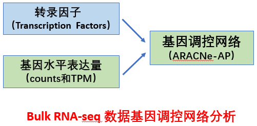

# 2 输出

## 2.1 基因调控网络

调控网络分析需要样本量不小于100个，本流程使用软件[ARACNe-AP](https://sourceforge.net/projects/aracne-ap/)<sup>1</sup>来完成分析，会生成转录因子和靶基因的调控关系表格，内容如如下所示：

| Regulator | Target | MI | pvalue |
| --- | --- | --- | --- |
| MS4A8 | SRGAP3-AS2 | 1.1192633 | 9.82e-05 |
| MAPK8IP3 | SRRM2 | 0.7965593 | 9.82e-05 |
| ARHGEF39 | FANCG | 0.7178108 | 9.82e-05 |
| ZNF786 | MRPS11 | 0.6577411 | 9.82e-05 |
| TERF2 | GLG1 | 0.6032281 | 9.82e-05 |

注：  
Regulator：转录因子的SYMBOL ID；  
Target：靶基因的SYMBOL ID；  
MI<sup>2</sup>：交互信息(Mutual Information)，度量两个变量间的依赖关系；  
pvalue：显著性互作对的多重假设检验的p值。

# 3 参考文献

- [1] Alexander L , Giorgi F M , Gonzalo L , et al. ARACNe-AP: gene network reverse engineering through adaptive partitioning inference of mutual information[J]. Bioinformatics(14):14.
- [2] Steuer R , Kurths J , Daub C O , et al. The mutual information: Detecting and evaluating dependencies betweenvariables[J]. Bioinformatics(suppl_2):suppl_2.